# projekt_ML_Insurance

# 3 Modelowanie

## 3.1 Model podstawowy

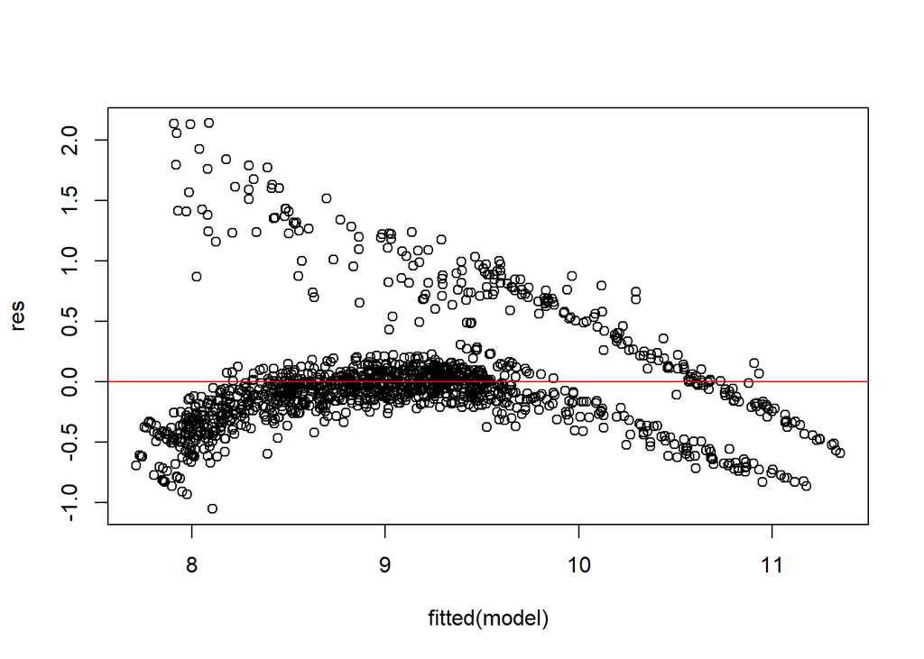

```r
model <- lm(charges_log ~ age + bmi + children + region + is_male + is_smoking, data = df)
sum_m <-summary(model)
res <- residuals(model)
plot(fitted(model), res)
abline(h = 0, col = "red")
```

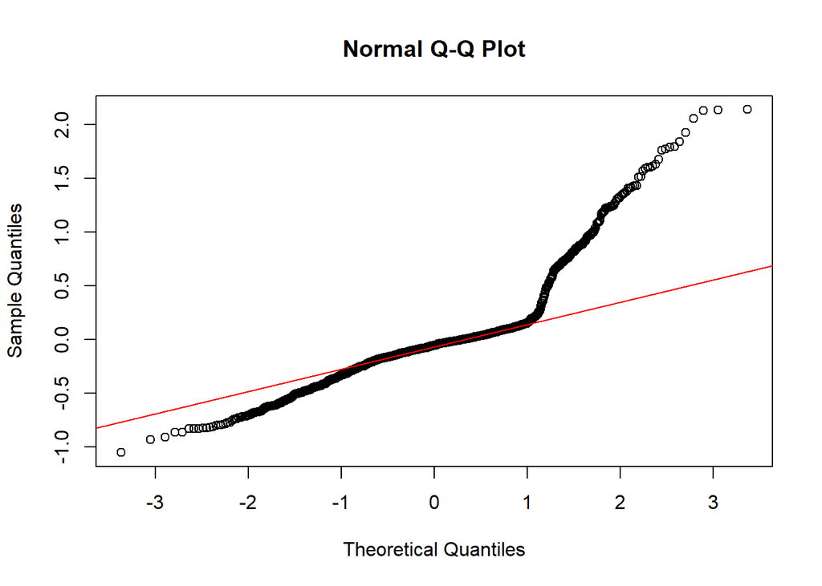

```r
qqnorm(res)
qqline(res, col = "red")
```

```r
print(sum_m$r.squared)
```

```
[1] 0.76992
```

Reszty wykazują silną heteroskedastyczność i odchylenia od normalności. W efekcie klasyczne błędy standardowe i testy parametryczne mogą dawać błędne wnioski.

Aby poprawić charakterystykę modelu dodano interakcję między wskaźnikiem BMI oraz paleniem. We wcześniejszym etapie analizy zaobserwowano, że wzrost BMI znacznie bardziej obciąża palących niż niepalących.

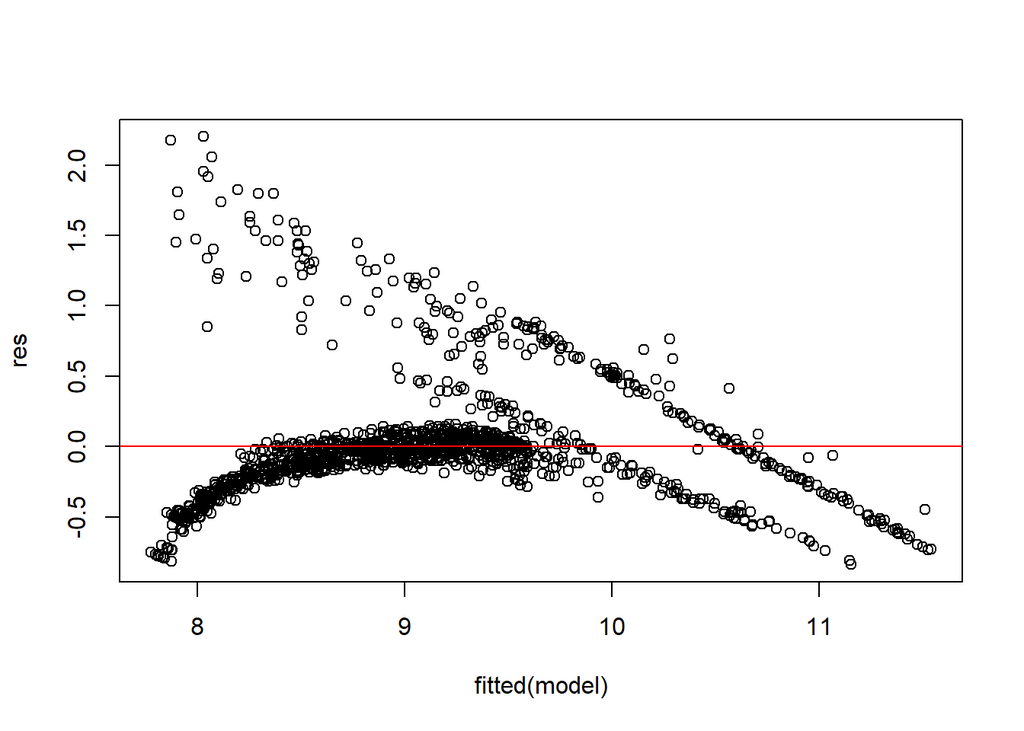

```r
model <- lm(charges_log ~ age + bmi * is_smoking + children + region + is_male, data = df)
sum_m <-summary(model)
res <- residuals(model)
plot(fitted(model), res)
abline(h = 0, col = "red")
```

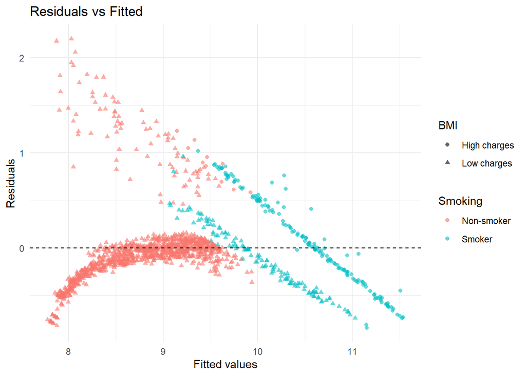

```r
df_plot <- data.frame(
  fit        = fitted(model),
  res        = residuals(model),
  is_smoking = factor(ifelse(df$is_smoking, "Smoker", "Non-smoker")),
  bmicat     = factor(ifelse(df$charges > 30000, "High charges", "Low charges"))
)

ggplot(df_plot, aes(fit, res, color = is_smoking, shape = bmicat)) +
  geom_point(alpha = 0.6) +
  geom_hline(yintercept = 0, linetype = "dashed") +
  scale_shape_manual(values = c("High charges" = 16, "Low charges" = 17)) +
  labs(x = "Fitted values", y = "Residuals",
       title = "Residuals vs Fitted",
       color = "Smoking", shape = "BMI") +
  theme_minimal()
```

```r
print(sum_m$r.squared)
```

```
[1] 0.7853765
```

Po dodaniu interakcji wartość współczynnika determinacji nieznaczenia wzrosła, jednak charakterystyka modelu nie poprawiła się. Wciąż widoczne są systematyczne niedoszacowania.